# Data Manipulation Cont’d

Neil Lund

2024-09-17

# Picking up where we left off

```r
library(tidyverse)
library(tidycensus)
url<-"https://github.com/nonviolent-action-lab/crowd-counting-consortium/raw/master/ccc_compiled_2017-2020.csv"
ccc<-read_csv(url)
ccc_by_state<-ccc|>
  group_by(state)|>
  summarize(events = n())
state_income <- get_acs(geography = "state",
              variables = c(medincome = "B19013_001"),
              year =2017)|>
  filter(!is.na(estimate))

state_keys<-data.frame('state.name' = state.name,
                       'state.abb' = state.abb
                       )
ccc_states<-ccc_by_state|>
  left_join(state_keys, by=join_by(state == state.abb))|>
  left_join(state_income, by=join_by(state.name == NAME))
```

# ggplot

We’ll generally use `ggplot` in this course instead of base plotting functions. Some key differences between `ggplot` and base plots are:

1. `ggplot` produces an R object that you can manipulate.
2. You can add elements to a `ggplot` object by using the `+` sign.
3. `ggplot` objects will follow somewhat consistent syntax regardless of what you’re producing.

## ggplot base

The base ggplot object will take a `data` argument and an aesthetic mapping that uses the `aes` (aesthetics) function. `aes` will generally contain, at a minimum, an `x` or `y` value.

Our plot

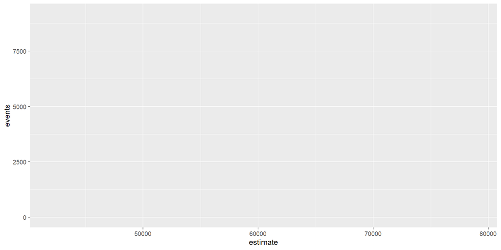

```r
plt<-ggplot(ccc_states, aes(x=estimate, y=events))

plt
```

## ggplot geometry

Now we need to populate the space with data. We’ll use “geometries” like `geom_point()`, `geom_bar()`, `geom_density()` etc. to specify the kind of plot we want.

Note we use the `+` to add more stuff to our existing plot:

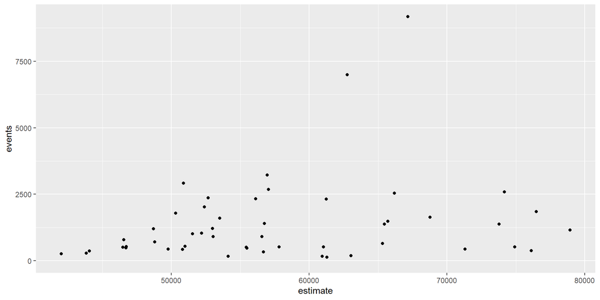

```r
# the intial plot:
plt<- ggplot(ccc_states, aes(x=estimate, y=events))

# now with some geometries:

plt<- plt +
  geom_point()

plt
```

## ggplot axes

`ggplot` syntax allows you to build plots step-by-step, adding new stuff as you go and then checking your results. I might want to add axis labels:

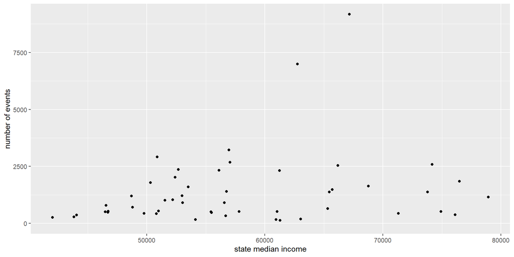

```r
plt<- ggplot(ccc_states, aes(x=estimate, y=events))

plt<- plt +
  geom_point()

# now with axis labels
plt<-plt +
  ylab("number of events") +
  xlab("state median income")

plt
```

## ggplot themes

I can also alter the theme or make additional aesthetic changes as I go. I’m personally not a huge fan of the default ggplot theme so you’ll often see calls to `theme_bw()` or `theme_minimal()` in my code. You can check out the various theme options [here.](https://ggplot2.tidyverse.org/reference/ggtheme.html)

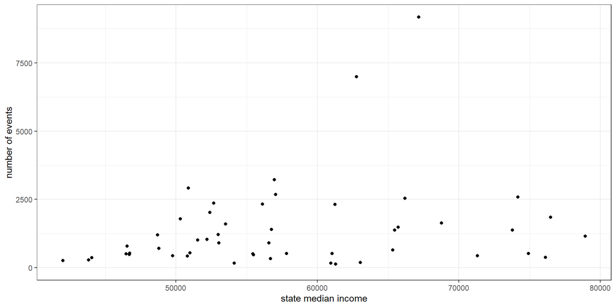

```r
plt<- ggplot(ccc_states, aes(x=estimate, y=events))

plt<- plt +
  geom_point()

plt<-plt +
  ylab("number of events") +
  xlab("state median income") +
  theme_bw()

plt
```

## ggplot additional geometry

`ggplot` objects aren’t limited to a single geometry. If we wanted to add something like a smoothed trend line to this data, we just need to add `geom_smooth()` to the existing plot:

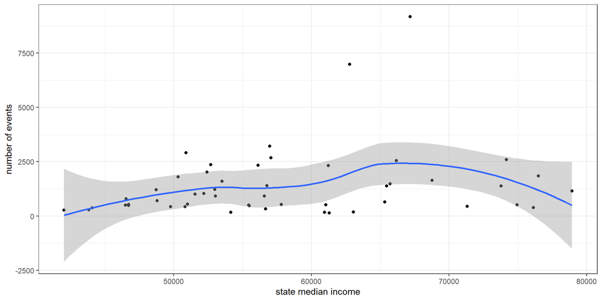

```r
plt<- ggplot(ccc_states, aes(x=estimate, y=events))

plt<- plt +
  geom_point()

plt<-plt +
  ylab("number of events") +
  xlab("state median income") +
  theme_bw()

plt <- plt + geom_smooth()

plt
```

## ggplot resources

Aside from the [extensive online documentation](https://ggplot2.tidyverse.org/reference/), the [R-graph Gallery is a good showcase](https://r-graph-gallery.com/) for things you can do.

## Exercise

https://github.com/Neilblund/GVPT628-Fall2024/blob/main/Week%204/ggplotting_exercise.Rmd

# Working with dates

We’ll often need to work with dates and times in R. These are a distinct data type in R with some unique methods for operating over them (which makes sense: date/time math isn’t like normal math but its also not like text data)

## Getting the current date

`Sys.Date()` and `Sys.time()` can be used to return the current date at the locale where R is running (keep in mind this could be different if you’re in a different time zone!)

```r
Sys.Date()
```

```
[1] "2024-09-17"
```

```r
Sys.time()
```

```
[1] "2024-09-17 17:58:26 EDT"
```

## Date formatting

We can convert something to a date type using `as.Date()`.

R dates need to formatted as YYYY-MM-DD or else R will not recognize them.

This won’t work:

```r
as.Date("9/17/2024")
```

```
Error in charToDate(x): character string is not in a standard unambiguous format
```

But this will

```r
as.Date("2024-09-17")
```

```
[1] "2024-09-17"
```

Strangely, this also will:

```r
as.Date(19983)
```

```
[1] "2024-09-17"
```

## Date conversion

Fixing formats can be tedious.

```r
as.Date("9/17/2024", format='%m/%d/%Y')
```

```
[1] "2024-09-17"
```

| **Specifier** | **Description** |
| --- | --- |
| %a | Abbreviated weekday |
| %A | Full weekday |
| %b | Abbreviated month |
| %B | Full month |
| %y | Year without century |
| %Y | Year with century |
| %d | Day of month (01-31) |
| %m | Month of year (01-12) |

## lubridate

The `lubridate` ([link](https://lubridate.tidyverse.org/)) package is a little less cumbersome to use. This should be loaded automatically as part of the tidyverse.

lubridate provides some shorthand functions to parse different date formats. `dmy()` will parse day-month-year format, `ymd()` for year-month-day etc.

```r
dmy("17-09-2024")
```

```
[1] "2024-09-17"
```

```r
mdy("9/17/2024")
```

```
[1] "2024-09-17"
```

## Accessing date parts

lubridate also provides methods for accessing/manipulation part of a date

```r
date<- mdy("9/17/2024")

year(date)
```

```
[1] 2024
```

```r
month(date)
```

```
[1] 9
```

```r
day(date)
```

```
[1] 17
```

```r
# add 100 years to the date
year(date)<-year(date) + 100
```

## Working with dates programmatically

https://github.com/Neilblund/GVPT628-Fall2024/blob/main/Week%204/dates.Rmd

# Recoding

We’ll often need to make categorical variables have a different set of categories. We can use `case_when` to accomplish this.

## ANES 2020 data

We can use the 2020 ANES data as an example

```r
#install_github("jamesmartherus/anesr")
library(tidyverse)
library(anesr)


data("timeseries_2020")

timeseries_2020<-timeseries_2020|>
    mutate(partyid = haven::as_factor(V201231x) )
```

## ANES 2020 data

[Documentation](https://electionstudies.org/data-center/2020-time-series-study/)

Here’s the party ID variable, how do we recode this to a 3 category measure?

```r
timeseries_2020|>
  group_by(partyid)|>
  summarize(n = n())
```

| partyid | n |
| --- | --- |
| -9. Refused | 31 |
| -8. Don't know | 4 |
| 1. Strong Democrat | 1961 |
| 2. Not very strong Democrat | 899 |
| 3. Independent-Democrat | 975 |
| 4. Independent | 968 |
| 5. Independent-Republican | 879 |
| 6. Not very strong Republican | 833 |
| 7. Strong Republican | 1730 |

## ANES 2020 data

In general terms, we want to make

| 7 Category | 3 category |
| --- | --- |
| Strong Republican | Republican |
| Not Very Strong Republican | Republican |
| Independent Republican | Republican |
| Independent | Independent |
| Independent Democrat | Democrat |
| Not Very Strong Democrat | Democrat |
| Strong Democrat | Democrat |

## if else

We can think of the problem as a series of if-else statements:

```
If party ID is Strong Republican then PID 3 is Republican,

else if Party ID is Not Very Strong Republican then Republican,

else if ...
```

## case_when

The `case_when` function will implement this logic. We’ll state a condition, followed by a tilde and then a new label for all cases where that condition is true, then we’ll state additional outcomes if that condition is false.

```r
timeseries_2020<-timeseries_2020|>
  mutate(pid3cat = case_when(str_detect(partyid, "Democrat") ~ "Democrat",
                             str_detect(partyid, "Republican") ~ "Republican",
                             partyid == "4. Independent" ~ "Independent"
                             ))
```

## checking your work

This tends to be one of the more error prone methods, so always check your work afterword by comparing the old and new variables to each other. One easy way to do that is with `select` and `distinct`

```r
timeseries_2020|>
  select(partyid, pid3cat)|>
  distinct()
```

| partyid | pid3cat |
| --- | --- |
| 7. Strong Republican | Republican |
| 4. Independent | Independent |
| 3. Independent-Democrat | Democrat |
| 6. Not very strong Republican | Republican |
| 2. Not very strong Democrat | Democrat |
| 1. Strong Democrat | Democrat |
| 5. Independent-Republican | Republican |
| -9. Refused | NA |
| -8. Don't know | NA |